# Climate Adaptation of Democracy

DAC Fall 2026

**Søren Damsbo-Svendsen**

University of Copenhagen

Kasper M. Hansen

University of Copenhagen

Morten A. D. Larsen

Danish Meteorological Institute

September 23, 2026

## The CAD project

- **Climate Adaptation of Democracy:**
  - Climate impacts on environmental  
    and democratic attitudes
  - 2026–2029
- Funded by the Independent Research Fund Denmark (DFF)
- Partners:
  - **DMI: Morten A. D. Larsen from the Danish Meteorological Institute**
  - Also: The Natural Hazards Council, Kystdirektoratet, Operate, Epinion, Scalgo
  - Academics: Pat Egan, Matto Mildenberger, Peter Howe
- **Three project legs** – presentation is about the main leg:
  - a ‘**preplanned natural experiment**’ on storm surge…

[figure not shown]

## Motivation

- Growing but not yet mature literature on climate-related events  
  and their effect on climate attitudes and political opinions/behavior
- **Methodologically:** increasing awareness of the **difficulties in designing**  
  these post-hoc ‘natural experiments’
  - e.g., measurement, definition of events/exposure, power
- **Theoretically:** no one has focused on the stress that the **broader political system** is put under when its **citizens react to flooding** and other climate events
  - e.g., do citizens still expect **the authorities** to protect them?
  - do they trust **politicians** past the next election?
  - would the **local community** step in?
- **Stakes:** if floods raise **citizens’ needs** while lowering their belief that politics can **help** them, **democracy** is put under stress

## Question

> *How do adverse local climate events affect **citizens’ attitudes towards democracy and the green transition*** [part 1]*, and what **strategies for communication** can help create effects that are environmentally and democratically sustainable* [part 2]*?*
- **Data:** one **survey** wave fielded shortly after a storm surge (repeated)
  - leverage is in the **sampling** and high-resolution **flood measurement**  
    (all Danish addresses in flood risk zones, event-driven CPR registry draw)
- **New:**
  - design, sampling, outcomes, estimation fixed **before** the storm
  - flooding **modelled** at address level rather than self-reported
  - outcomes about the broader **political system**, not just climate attitudes

## Sampling frame

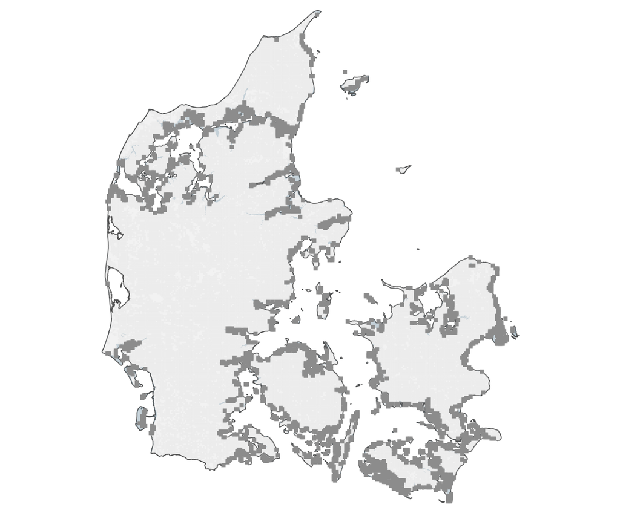

DMI’s 100-year risk zone and qualifying cells

- **1 km grid cells** = communities
- At least one address in the **100-year risk area**
- **Permanent residents** only
- **2,576 cells** nationally
- Based on:
  - **DAR** (addresses)
  - **BBR** (buildings)
  - Danish national **grid**
  - DMI’s flood **risk polygons**

## Treatment = wet declared cells

- **(A) Declared** storm surge
  - rarer than a **20-year** event
- and **(B)** modelled **inundation** (water)
  - at least one **wet address**
- **Depth thresholds** *TBD*
  - does “treated” *require*  
    *XX* mm of water
  - does “control” *allow*  
    *YY* mm of water

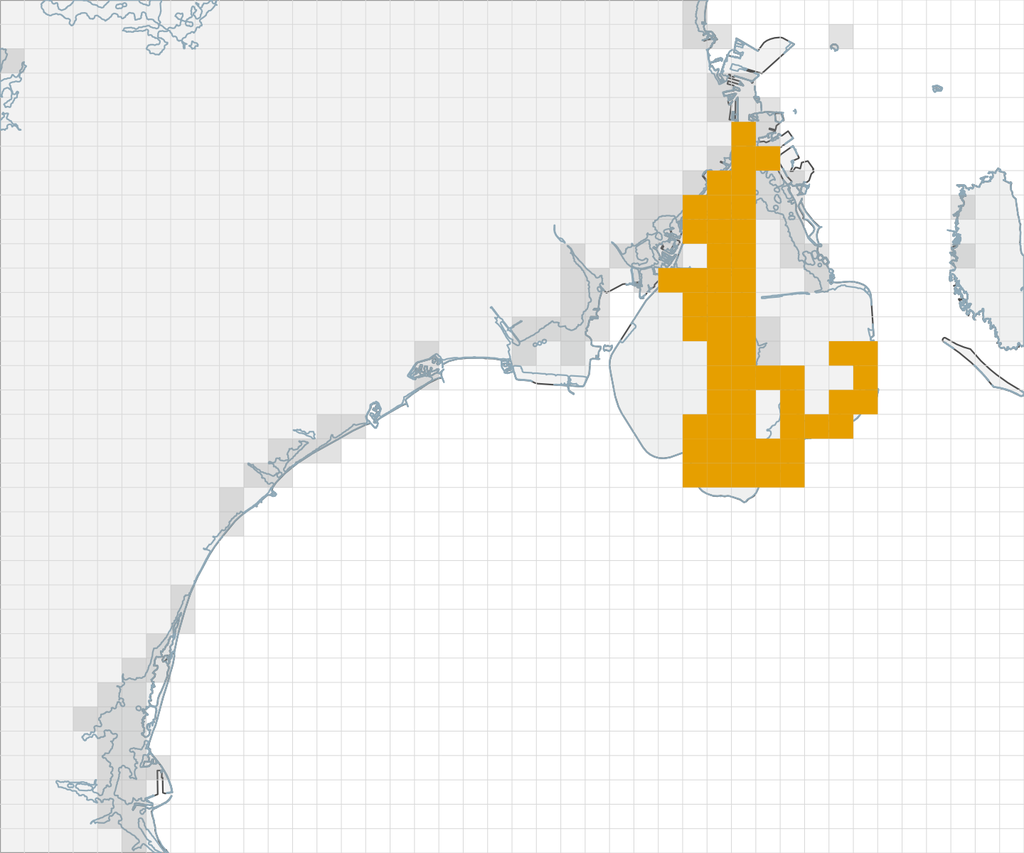

Example: Declared storm surge

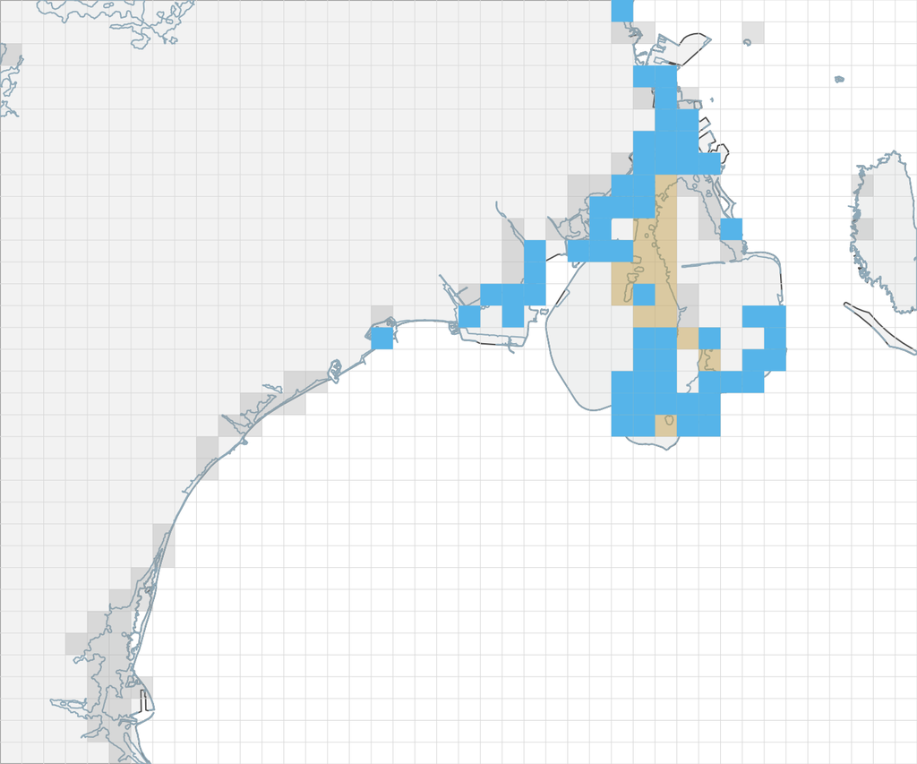

Example: (Modelled) wet

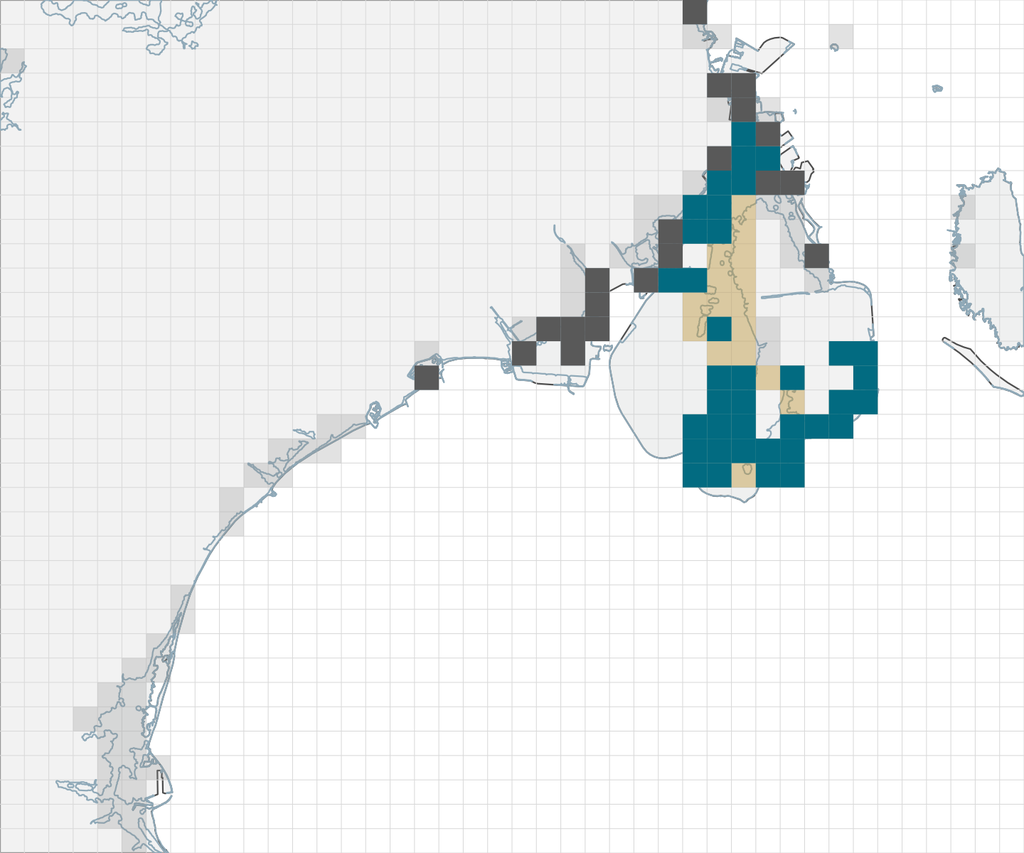

Example: Declared AND wet = treated, wet-only = excluded from control

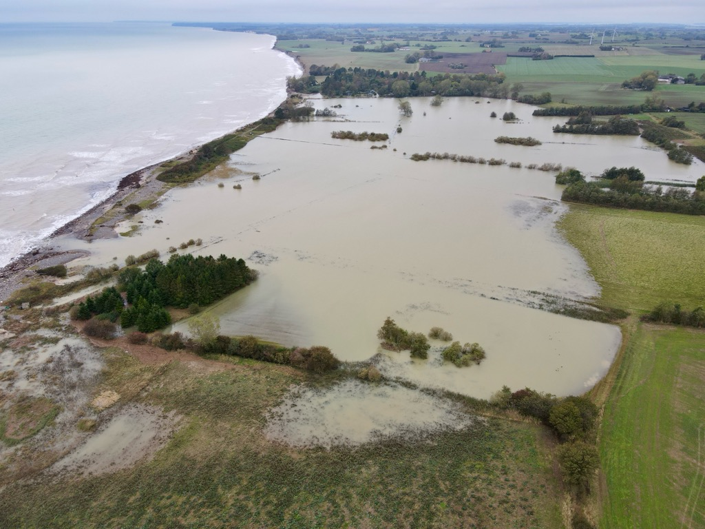

Storm Babet, 21 October 2023 — Oddermose, Møn. Photo: Bdarg, Wikimedia Commons, CC BY-SA 4.0

## Controls = dry cells

- Modelled **dry** = eligible control
- **Undeclared wet** → excluded
- **1 km buffer** around treated → excluded
- Two types of control cells:  
  **local** and **distant**
- **Combined** in main specification (both are matched on elevation, coast distance, density)

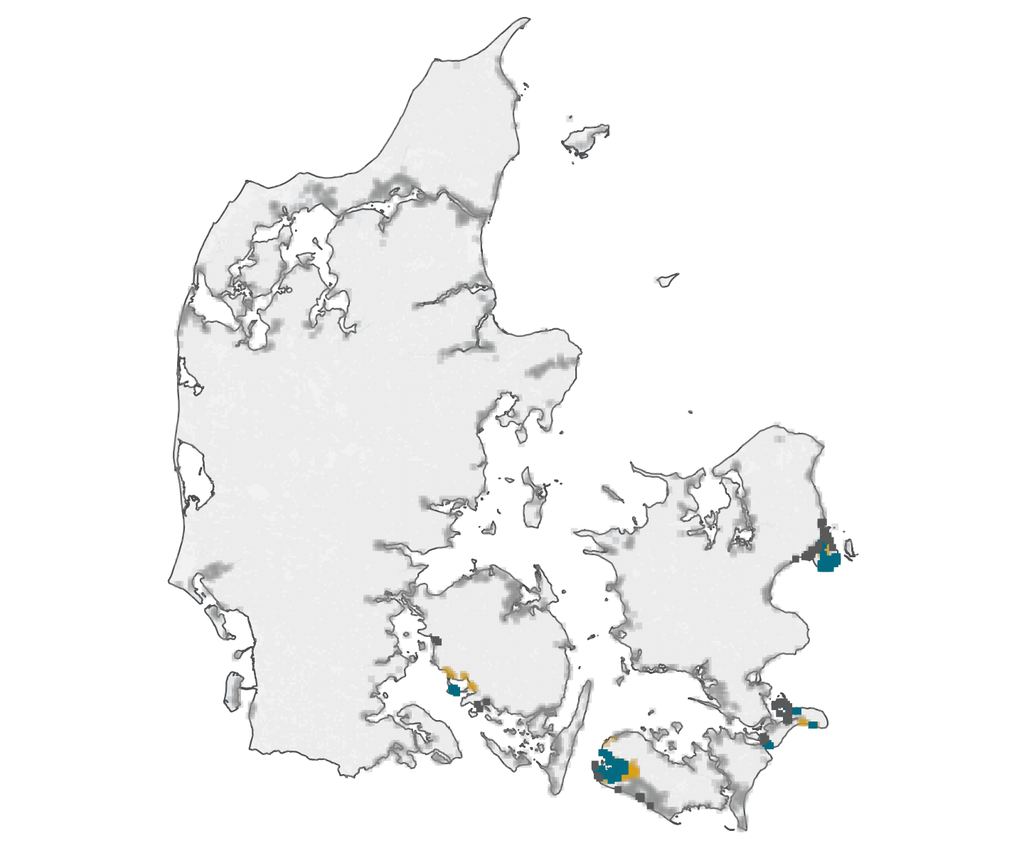

Example: Treated and excluded cells

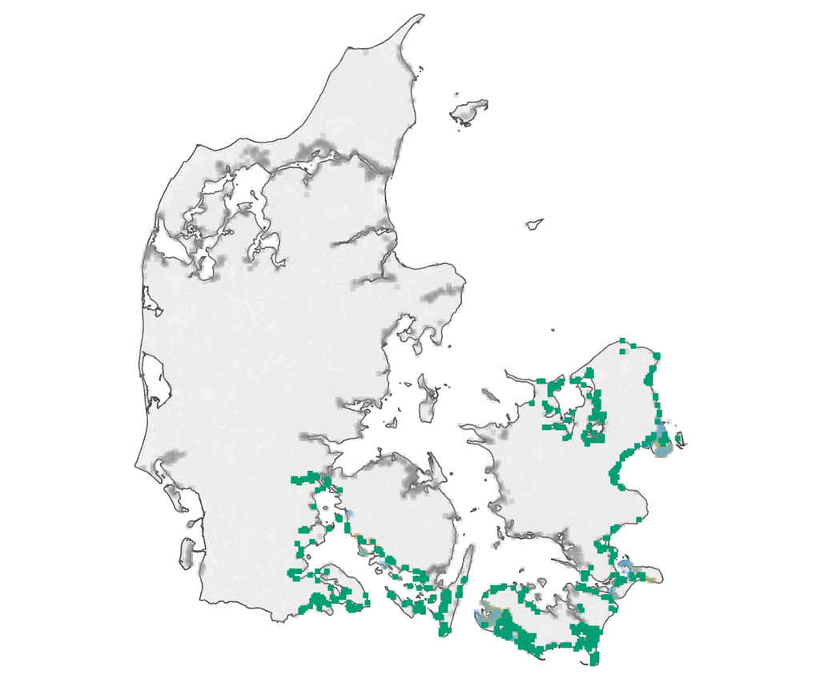

Example: Local controls — same warning district, or near treated

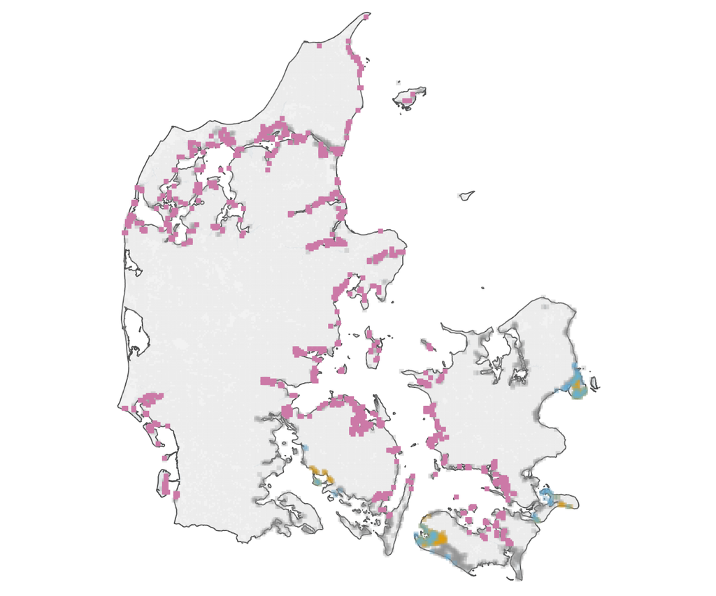

Example: Distant controls — everywhere else in the frame

## Sampling of *people*

- **All treated** cells
- **Control** cells matched **bin by bin** on elevation, pop density, distance to coast
- **1 to 50 households** (cap) sampled randomly from each cell — controls thinner
- **1 person** aged 18+ sampled randomly from each household
- *n* is decided by the event: from a few thousand to ~20-30k (treated-*n* = local-*n* = distant-*n*)
- Study cells → addresses → CPR registry (people) → invitation via Digital Post (~4 weeks after storm)

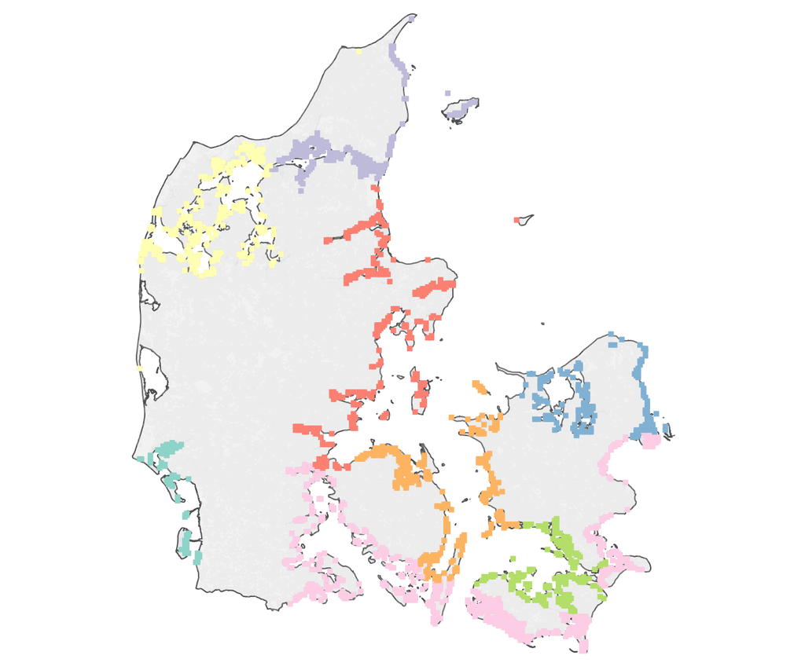

## We design for the “community channel”

- Water reaches **cells** far more often than **people**
- At most **5–15%** of a treated cell’s addresses in the flood zone
- Hard to identify flooded individuals
- Cell effect is **community effect** + **personal effect**, mostly the first
- Community effects are policy-relevant, not just a proxy
- (Note: we’ll also pursue estimation of **individual-level** estimands  
  and of moderation by communities’ **‘water dose’**)
- So: we select **outcomes** that may be affected in someone who **witness** a local flood

## Outcomes

**Five short indices, 3–5 items each:**

- **P1 — expected protection and support** — *will **myndighederne** be there for me?* A flood is the state failing to keep people dry, and the state turning up afterwards
- **P2 — demand for climate adaptation policy** — should the state **build** the defences, and would you **pay** for them? Water plausibly *increases* support
- **P3 — can politicians protect?** — perceived capacity and will. Coastal defence pays off long after the next election, so this asks whether people believe democratic politics can act on that timescale
- **P4 — expected support from local community** (social capital) — if the state or municipality is doubted, do neighbours etc. take its place
- **C1 — climate concern and importance** — do floods move climate attitudes at all? Three DNES items, directly comparable to existing research

**Only these five will be preregistered.**

## Question examples

> If a serious flood hit my area, I could count on help from **the authorities**.

> P1 — expected protection and support

> The government should **invest heavily in climate adaptation** — coastal protection, flood barriers, drainage.

> P2 — demand for climate adaptation policy

> Politicians would rather spend money on **something voters can see before the next election** than on protection against flooding twenty years from now.

> P3 — can democratically elected politicians protect?

> If a serious flood hit my area, **neighbours and the local community would help each other**.

> P4 — expected support from community and civil society

## Also in the questionnaire

1. **Checks** — perceived **flood likelihood** and preparedness, self-reported **exposure**, **summer-house** ownership
2. **Supplementary outcomes**
   - **vote** intention, retrospective **evaluation** of government and municipality
   - **deservingness** of compensation, **willingness** to help
   - democratic **satisfaction** and institutional **trust**, responsibility **attribution**
3. **Covariates** — age, gender, origin, education, income, savings, housing tenure
4. **Simple embedded framing experiment(s)**
   - e.g., community-orientation vs individual-responsibility

## Identification

- Post-event, cross-sectional
  - design-stage **matching + regression** ladder
  - identification by **as-if-random inundation** within the risk area
  - given similar elevation, distance to coast, pop density, and surrounding water (fetch)
- **Quasi-random physics** decide where water actually goes  
  (storm track, wind, micro-elevation)
- **Threat:** residential sorting, e.g., onto slightly **higher ground** or to a better view
  - wealth, education
- **Covariate ladder** with 9 rungs (all reported), 3-17 cell-level **covariates**
  - **physical** core (5) → **district SES** (share owners, household wealth, share tertiary education) → cell’s **respondent composition** [primary]→ outcome **predictors** (e.g., lagged vote, origin)

# Conclusions

- *RQ: How do adverse local climate events affect **citizens’ attitudes towards democracy and the green transition** […]?*
- **The bigger question:** whether **democracy can adapt** as climate risks keep rising — whether being flooded changes what citizens **trust and expect**: the state protecting them, politicians acting ahead of disaster, neighbours coming together
- Core will be **preregistered** before the 2026/27 storm season
  - an addendum covers storm-specifics: **sample** etc.
- Honest concern: low **power** (as in most similar research)
- **All comments are welcome:**
  - sampling/design, outcomes, identification, power
  - paper-writing/publishing perspectives, ideas for later

# Thank you

# Appendix

## P1 — expected protection and support

- Q3.5 If a serious flood hit my area, I trust that the emergency response would reach everyone who needed it.
- Q3.6 If a serious flood hit my area, I trust that help would be distributed fairly among those affected.
- Q3.6b If a serious flood hit my area, I expect that residents would largely be left to cope on their own. **(R)**
- Q3.6c If a serious flood hit my area, I could count on help from the authorities.

## P2 — demand for climate adaptation policy

- Q4.10 The government should invest heavily in climate adaptation measures (e.g., coastal defences, flood barriers, improved drainage).
- Q4.21 I would be willing to pay higher taxes if the money went to large-scale climate adaptation in Denmark, such as coastal protection and sea barriers.
- Q4.10b Climate adaptation should have lower priority than other public tasks in the coming years. **(R)**
- Q4.7 More public resources should be allocated to protecting the climate.

## P3 — whether politicians can and will protect

- Q3.2 Politicians take account of what citizens want when they make decisions about the climate.
- Q4.16 Even though coastal protection and other flood defences only pay off long after the next election, I expect politicians to carry them through.
- Q4.16b Politicians are not able to protect us against sea-level rise, flooding and other consequences of climate change. **(R)**
- Q4.16c Politicians would rather spend money on something voters can see before the next election than on protection against flooding twenty years from now. **(R)**

## P4 — expected support from community and civil society

- Q3.6d If a serious flood hit my area, neighbours and the local community would help each other.
- Q3.6e If a serious flood hit my area, volunteers and local associations would step in.
- Q3.6f If a serious flood hit my area, I would get help from people I do not know.
- Q3.6g If something serious happened where I live, people would be able to manage it together.
- Q3.16b If a serious flood hit my area, most people would mainly look after themselves. **(R)**

## C1 — climate concern and importance

- Q2.1 Climate change is the greatest challenge of our time.
- Q2.2 I am afraid that climate change will have consequences for me and my loved ones.
- Q2.2c I am willing to accept a lower standard of living in order to protect the climate.

## Sampling, step by step

1. **Treated** = cells that are **declared and wet**.
2. **Drop from control eligibility:** every wet cell, and the 1 km ring around the treated set.
3. **Split what remains into two arms:** *local* — same warning district, or within 20 km of a treated cell — and *distant*, the rest of the frame.
4. **Pick the matching grid by rule:** 4 x 4 x 3 = 48 bins where support allows, else 3 x 3 x 2 or 2 x 2 x 2.
5. **Cut the bins** at quantiles of the **treated** distribution (elevation, coast distance, address density) and place treated and eligible cells in a bin.
6. **Treated invitations:** up to **50 addresses** per treated cell, sampled at random — all of them if the cell has fewer than 50.
7. **Each bin’s target *n*, per control arm** = the treated invitations in that bin — so the treated share is **1/3** with both arms (**1/2** with one of them).
8. **Distribute that target *n* across the bin’s eligible cells:**
   1. evenly, in rounds, while remaining invitations outnumber eligible cells;
   2. one each to a **random subset** when they do not (report under-fill if the cells run out of addresses)
9. **Within each selected cell:** draw the allocated number of **addresses at random**.
10. **Send the address list to CPR** and request the extract — residents at those addresses.
11. **Before any outcome data are seen:**
    1. describe the realised sample — cells per arm, bin fill, under-fill, and balance on cell-level BBR variables — and recompute **power** on the realised numbers;
    2. file the **event addendum** to the preregistration: the storm and the sample.
12. **Hand the extract to Epinion**, who invite by **Digital Post** — about 4 weeks after the surge.

## Controls — local, distant, and pooled

- **Local** — same warning district as a treated cell, or within **20 km**. Above all the same **latent probability of flooding**: same water, same surge regime, cells that could have been treated. With it the same warning, news and municipal response — and closer **socio-geographically**: settlement type, labour market, political culture. Nearer on what we cannot measure.
- **Distant** — the rest of the frame: **(relatively) far from actual exposure** to this surge. No warning, no local coverage — still coastal, still at risk in principle.
- **Within local**, declared-dry against undeclared-dry asks whether the **declaration alone** moves attitudes on dry land.
- **Why both arms:** each buys off a different problem. Local controls may have been **moved by the storm themselves** — spillover — so treated-vs-local runs small. Distant controls carry whatever **regional confounding** the matching missed, in either direction. Assume one away and the other bounds it. Never clean, but a diagnostic: agreement means both are small, divergence tells us which to argue about.
- **The headline pools them — for power.** Either arm alone is around half the control invitations, too much precision to spend on a diagnostic. Pooling holds because **both arms are matched on the same cell specifications** — elevation, coast distance, address density